# Final assignment group 4

Deepika Dilip, Tora Mullings, Daniel Sullivan, Deepa Sharma, Bikram Barua, Newman Okereafor

2022-11-24

# Abstract:

*Introduction:* Maternal mortality is a leading public health issue in Bangladesh, with [173 deaths per 100k births](https://www.macrotrends.net/countries/BGD/bangladesh/maternal-mortality-rate). Yet with improvements in public health surveillance, a preventative responsive could be better informed with biomarker data and accurate risk predictions.

*Methods:* For this project, we utilize multinomial models to quantify the contribution of biomarkers in predicting mortality risk. We start with multinomial regression, followed by ordinal regression and an xgboost model.

*Discussion:* The use of supervised learning to predict outcomes using biomarkers can be a clinically-relevant tool to reduce mortality burden.

# Key words:

maternal health, clinical outcomes

# Introduction:

Maternal mortality is a leading public health issue in Bangladesh. Advances in public health outreach and medical pipelines have reduced maternal mortality rates, but there remains a glaring gap, especially when considering additional factors, such as socioeconomic status. One of the [WHO Sustainable Development Goals](https://www.who.int/data/gho/data/themes/topics/indicator-groups/indicator-group-details/GHO/maternal-mortality) was to reduce the global mortality ratio to less than 70 deaths per 100k births

Here, we further explore mortality risk as a product of standard clinical indicators. We obtained this dataset from the [UCI repository](https://archive.ics.uci.edu/ml/datasets/Maternal+Health+Risk+Data+Set). Data was aggregated from different sites, including rural and urban health centers.

According to the WHO approximately 810 women die daily due to pregnancy complications (1). With such a high rate of death associated with childbirth it is important to maximize early interventions in high-risk pregnancies in order to monitor and start early intervention to save both the lives of the mother and child. Because of this need, pregnancy has been the focus of many data scientists’ research in developing many predictive algorithms to try and aid in identifying at risk pregnancies, best emergency interventions and various other aspects to help both mothers and doctors. For this reason, we want to look at identifying low-, mid-, and high-risk pregnancies through regression and machine learning methods in order to aid in identifying individuals who could be helped through early intervention.

# Literature review:

At-risk pregnancies remain a vital research topic despite technological advances and a shrinking pregnancy/childbirth mortality rate. Predictive modeling has been implemented in several ways to reduce pregnancy risks. There are three major groups of studies that have been performed. The largest group predicted risks and complications involved with the pregnancy in specific scenarios (3) as we are trying to assess with our data set. Many papers also covered predicting delivery methods and successful vaginal delivery (2). The last significant area of study is predicting in-vitro fertilization success rates.

Our analysis concerns at-risk pregnancies using specific clinical indicators to predict risk. Most studies that predict complications do it in a much more specific scope. For example, some studies only predict preterm birth or vaginal birth complications while our approach focuses on high-risk births and uses basic vitals.

Additionally, our analysis works through generalized linear models and progresses into simple machine learning models, whereas further studies implement more sophisticated models. However, there was not a consensus of how these studies approached this type of analysis. For example, some took a similar approach to us using gradient boosting however building on it by adding a random forest and Adaboost ensemble(5). Others took a range of approaches some examples include univariate and multivariate approaches(6), as well as K-means clusters, naive Bayes, logistic regression, and multiple types of neural networks.(4)

# Methodology:

## Exploratory Data Analysis:

We started by creating exploratory plots to describe positive and negative correlations between predictors and our outcome (risk). We also wanted to make note of the nature of the relationship (e.g. linear or non-linear). Lastly, we used an unsupervised approach to classify patients and gain a better understanding of risk heterogeneity.

## Data Attributes

- `Age`: Any ages in years when a women during pregnant.
- `SystolicBP`: Upper value of Blood Pressure in mmHg, another significant attribute during pregnancy.
- `DiastolicBP`: Lower value of Blood Pressure in mmHg, another significant attribute during pregnancy.
- `BS`: Blood glucose levels is in terms of a molar concentration, mmol/L.
- `HeartRate`: A normal resting heart rate in beats per minute.
- `Risk Level`: Predicted Risk Intensity Level during pregnancy considering the previous attribute.

## Models Used:

### Multinomial Regression

First we partitioned the dataset using a 70-30 split. We initially fit a full model with all included variables as predictors. Next, we fit a series of multinomial models, starting with a full model. We then implemented feature selection based on statistical significance to improve accuracy.

### XGBoost

We also decided to try using a model that combined previous models with new ones, subsequently increasing accuracy. Therefore, we decided to fit the eXtreme Gradient Boosting algorthim from the `caret` package. In this case, however, we have to split our outcome: one model will predict high-risk while the other will predict medium-risk.

### Ordinal Models

Lastly, we used ordinal models as an alternative to multnomial regression.

# Experimentation and Results:

## Exploratory Data Analysis

### Correlation Plot:

We can start by making a correlation plot to compare continuous values. Age is positively correlated with systolic and diastolic blood pressure.

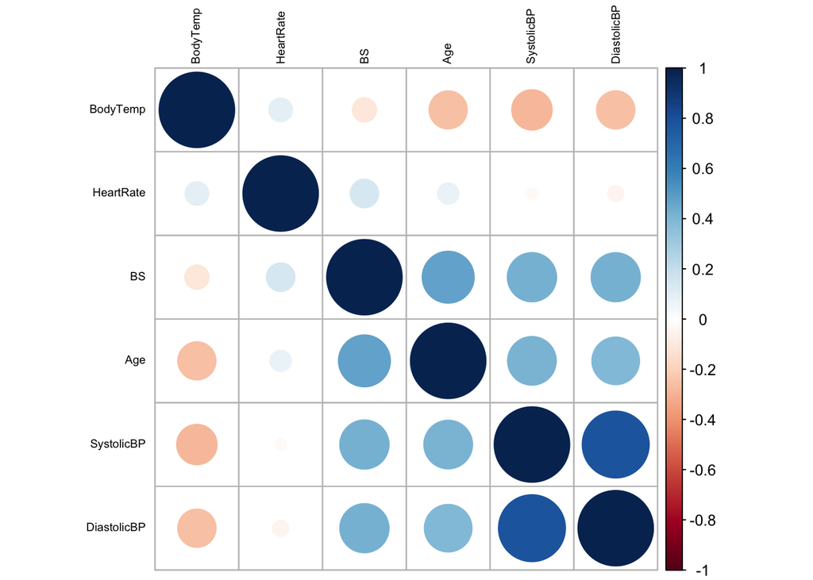

### Histograms:

The first step is visualizing data distribution by risk. Here we can see age is skewed, and the extremities of blood pressure and glucose levels are flagged as high risk.

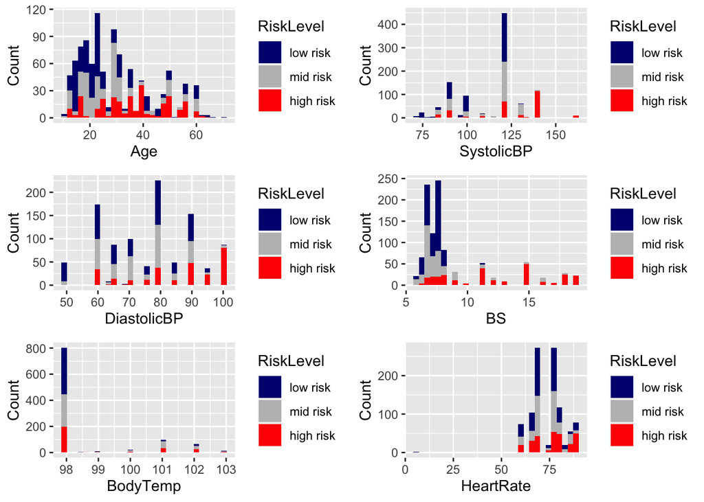

### Risk Distribution:

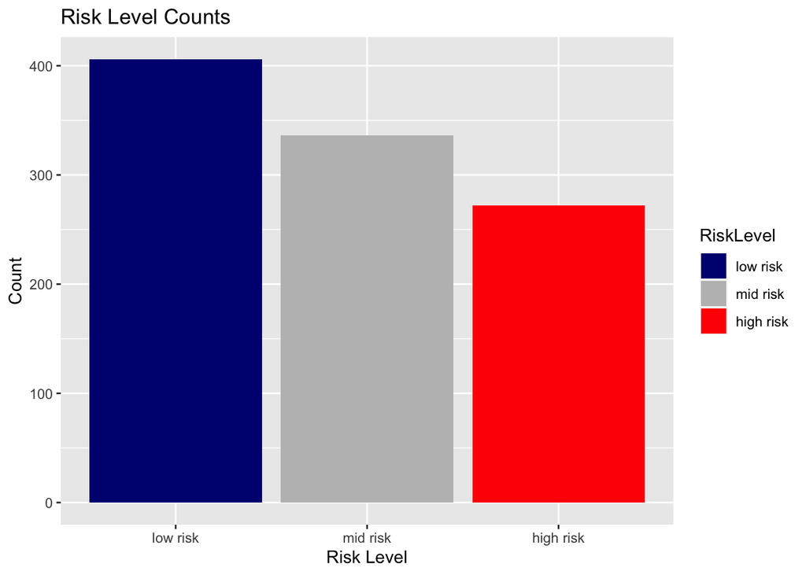

### Unsupervised Learning:

One approach we can take is implementing unsupervised clustering since many of the biomarkers are continuous. We can do this by forming a matrix of indicators and seeing if risk levels clusters. From this analysis, we see 6 distinct subgroups: 2 high-risk, 3 low-risk, and 1 mid- risk (with some heterogeneity).

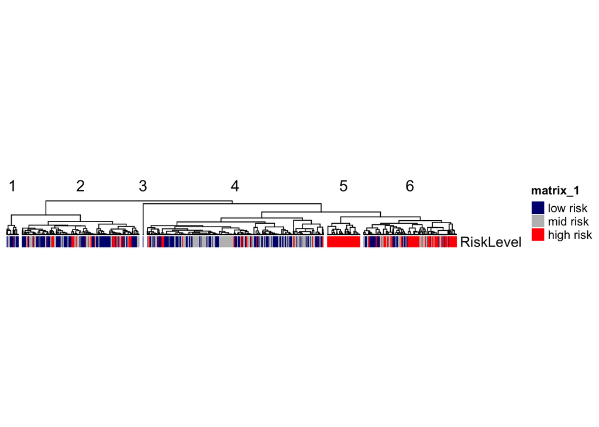

# Model Results

## Multinomial: Full Model:

| metric | Class: low risk | Class: mid risk | Class: high risk |
| --- | --- | --- | --- |
| Sensitivity | 0.6356589 | 0.4062500 | 0.7125000 |
| Pos Pred Value | 0.6307692 | 0.4020619 | 0.7307692 |

[output not shown]

## Multinomial: Blood Sugar and Systolic BP as Predictors:

| metric | Class: low risk | Class: mid risk | Class: high risk |
| --- | --- | --- | --- |
| Sensitivity | 0.7054264 | 0.2187500 | 0.6 |
| Pos Pred Value | 0.5290698 | 0.2876712 | 0.8 |

## Multinomial: Blood Sugar as Predictor:

| metric | Class: low risk | Class: mid risk | Class: high risk |
| --- | --- | --- | --- |
| Sensitivity | 0.9689922 | 0.0520833 | 0.6500 |
| Pos Pred Value | 0.5506608 | 0.3571429 | 0.8125 |

## XGBoost Model

### Predicting High Risk:

|  | x |
| --- | --- |
| Sensitivity | 0.9733333 |
| Specificity | 0.9875000 |
| Pos Pred Value | 0.9954545 |
| Neg Pred Value | 0.9294118 |
| Precision | 0.9954545 |
| Recall | 0.9733333 |
| F1 | 0.9842697 |
| Prevalence | 0.7377049 |
| Detection Rate | 0.7180328 |
| Detection Prevalence | 0.7213115 |
| Balanced Accuracy | 0.9804167 |

### `xBoost`: Predicting Medium Risk

|  | x |
| --- | --- |
| Sensitivity | 0.9808612 |
| Specificity | 0.9166667 |
| Pos Pred Value | 0.9624413 |
| Neg Pred Value | 0.9565217 |
| Precision | 0.9624413 |
| Recall | 0.9808612 |
| F1 | 0.9715640 |
| Prevalence | 0.6852459 |
| Detection Rate | 0.6721311 |
| Detection Prevalence | 0.6983607 |
| Balanced Accuracy | 0.9487640 |

## Ordinal: Full Model

| metric | Class: low risk | Class: mid risk | Class: high risk |
| --- | --- | --- | --- |
| Sensitivity | 0.620155 | 0.3958333 | 0.6125000 |
| Pos Pred Value | 0.640000 | 0.3486239 | 0.6901408 |

## Ordinal: Blood Sugar, Systolic Blood Pressure, Age

| metric | Class: low risk | Class: mid risk | Class: high risk |
| --- | --- | --- | --- |
| Sensitivity | 0.6356589 | 0.4375000 | 0.5875000 |
| Pos Pred Value | 0.5774648 | 0.4038462 | 0.7966102 |

## Ordinal: Blood Sugar, Systolic Blood Pressure

| metric | Class: low risk | Class: mid risk | Class: high risk |
| --- | --- | --- | --- |
| Sensitivity | 0.6201550 | 0.3958333 | 0.5875000 |
| Pos Pred Value | 0.5594406 | 0.3689320 | 0.7966102 |

## Ordinal: Blood Sugar

| metric | Class: low risk | Class: mid risk | Class: high risk |
| --- | --- | --- | --- |
| Sensitivity | 0.8914729 | 0.15625 | 0.6375000 |
| Pos Pred Value | 0.5693069 | 0.37500 | 0.8095238 |

## Summary of Results:

| model | accuracy | AIC |
| --- | --- | --- |
| mm_model1 | 0.5836066 | 1109.227 |
| mm_model2 | 0.5606557 | 1208.700 |
| mm_model3 | 0.5245902 | 1214.164 |
| mm_model4 | 0.5967213 | 1261.509 |
| ordinal1 | 0.5475410 | NA |
| ordinal2 | 0.5606557 | NA |
| ordinal3 | 0.5409836 | NA |
| ordinal4 | 0.5934426 | NA |

### GLM model construction:

We first tried to predict the level of risk involved with pregnancy using multinomial and ordinal regression modeling. Starting with all variables and then paring down based on correlation to risk level and co-linearity in predictors. We selected first age, systolic blood pressure, and blood sugar level as our first set of restricted predictors, followed by blood sugar and systolic blood pressure for our second.

# Discussion and Conclusions:

## Model Interpretation:

First, we look into the multinomial model assessing the accuracy of all predictors and pairing things down to try and improve the model. Starting with every variable, the multinomial model gives an error rate of 41%, which could be better. From here, we eliminated redundancy and low correlation values to the class level.

The first pared-down model consisting of Age, Systolic blood pressure, and Blood sugar showed an even worse error rate of around 44%. A pared-down model with blood sugar and systolic blood pressure had a missclassification rate of about 48%. The only improvement was upon making a model solely with blood sugar when the error rate dropped to 40%. This shows that the multinational regression clearly does not reflect or predict the data too well.

# References:

1 Trends in maternal mortality 2000 to 2017: estimates by who, unicef, unfpa, world bank group and the united nations population division. https://www.unfpa.org/featured-publication/trends-maternal-mortality-2000-2017. Accessed 10 Jan 2021.

2 Birara M, Gebrehiwot Y. Factors associated with success of vaginal birth after one caesarean section (vbac) at three teaching hospitals in addis ababa, ethiopia: a case control study. BMC Pregnancy Childbirth. 2013;13(1):1–6.

3 Gao C, Osmundson S, Edwards DRV, Jackson GP, Malin BA, Chen Y. Deep learning predicts extreme preterm birth from electronic health records. J Biomed Inform. 2019;100:103334.

4 Islam, Muhammed N, Mustafina, Sumaiya N, Mahmud, Tahsin, Khan, Nafiz I Machine learning to predict pregnancy outcomes: a systematic review, synthesizing framework and future research agenda

5 Lipschuetz M, Guedalia J, Rottenstreich A, Persky MN, Cohen SM, Kabiri D, Levin G, Yagel S, Unger R, Sompolinsky Y. Prediction of vaginal birth after cesarean deliveries using machine learning. Am J Obstet Gynecol. 2020;222(6):613–1.

6 Li Y-X, Bai Z, Long D-J, Wang H-B, Wu Y-F, Reilly KH, Huang S-R, Ji Y-J. Predicting the success of vaginal birth after caesarean delivery: a retrospective cohort study in china. BMJ Open. 2019;9(5):027807.

# Appendices:

## R statistical programming code.

```r
## ----setup, include=FALSE---------------------------------------------------------------------------------------
knitr::opts_chunk$set(echo = F, warning = F, message = F)


## ---------------------------------------------------------------------------------------------------------------
library(tidyverse)
library(ggplot2)
library(ggthemes)
library(corrplot)
library(reshape2)
library(knitr)
library(broom)
library(caret)
library(leaps)
library(MASS)
library(magrittr)
library(betareg)
library(pscl)
library(gtsummary)
library(nnet)
library(readr)
library(fastDummies)
library(ComplexHeatmap)
library(kableExtra)
library(xgboost)


## ---------------------------------------------------------------------------------------------------------------
MHRD<-read.csv("https://raw.githubusercontent.com/TheSaltyCrab/DATA621_Final/main/Maternal%20Health%20Risk%20Data%20Set.csv")


## ---------------------------------------------------------------------------------------------------------------
# MHRD<-MHRD%>% mutate(Risk_num = case_when(
#     str_detect(.$RiskLevel, "low risk") ~ "0",
#     str_detect(.$RiskLevel, "mid risk") ~ "1",
#     str_detect(.$RiskLevel, "high risk") ~ "2",
#     TRUE ~ as.character(.$RiskLevel)))
MHRD = MHRD %>% mutate(RiskLevel = factor(RiskLevel, levels = c("low risk", "mid risk", "high risk")))



## ---------------------------------------------------------------------------------------------------------------
set.seed(100)
trainingRows <- sample(1:nrow(MHRD), 0.7*nrow(MHRD))
training <- MHRD[trainingRows, ]
test <- MHRD[-trainingRows, ]


## ---------------------------------------------------------------------------------------------------------------
corrplot(cor( select_if(MHRD, is.numeric), use = "complete.obs"), tl.col="black", tl.cex=0.6, order='AOE')


## ---------------------------------------------------------------------------------------------------------------
lst.histogram = list()
for (i in names(MHRD)[1:6]) {
  MHRD.sub = MHRD %>% select(i, "RiskLevel")
  colnames(MHRD.sub) = c("value", "RiskLevel")
  lst.histogram[[i]] = ggplot(aes(value, fill = RiskLevel), data = MHRD.sub) + geom_histogram() + labs(x = i, y = "Count") + scale_fill_manual(values = c("low risk" = "navyblue", "mid risk" = "grey", "high risk" = "red"))
}
ggpubr::ggarrange(plotlist = lst.histogram, ncol = 2, nrow = 3)


## ---------------------------------------------------------------------------------------------------------------
ggplot(aes(RiskLevel, fill = RiskLevel), data = MHRD) + geom_bar(stat = "count") + labs(x = "Risk Level", y = "Count") + scale_fill_manual(values = c("low risk" = "navyblue", "mid risk" = "grey", "high risk" = "red")) + labs(title = "Risk Level Counts")


## ---------------------------------------------------------------------------------------------------------------
mat.MHRD = MHRD %>% select(-c("RiskLevel")) %>% as.matrix()
rownames(mat.MHRD) = rownames(MHRD)
mat.MHRD = t(mat.MHRD)
tree = hclust(dist(t(mat.MHRD), method = "euclidean"))
tree.groups = cutree(hclust(dist(t(mat.MHRD), method = "euclidean")), k = 6)

mat.risk = MHRD %>% select(c("RiskLevel")) %>% as.matrix()

Heatmap(t(mat.risk), cluster_columns  = tree, cluster_rows = F, col =c("low risk" = "navyblue", "mid risk" = "grey", "high risk" = "red"),  heatmap_height = unit(2, "cm"), column_split = 6)


## ---------------------------------------------------------------------------------------------------------------
lst.model.results = list()
mn_model<-multinom(RiskLevel ~ ., data=training, trace = F)
# data.frame(summary(mn_model)$coefficients/summary(mn_model)$standard.errors) %>% kable() %>% kableExtra::kable_styling(full_width = F)

predicted_scores <- predict (mn_model, test, "probs")
predicted_class <- predict (mn_model, test)

lst.model.results[['mm_model']][['accuracy']]  = mean(as.character(predicted_class) == as.character(test$RiskLevel))
lst.model.results[['mm_model']][['AIC']] = mn_model$AIC

# print(paste0("accuracy=",mean(as.character(predicted_class) == as.character(test$RiskLevel))))
# print(paste0("AIC=",mn_model$AIC))

as.tibble(t(confusionMatrix(data = predicted_class, reference = test$RiskLevel)$byClass), rownames = "metric") %>% filter(metric == "Sensitivity" | metric == "Pos Pred Value") %>% knitr::kable()


## ---------------------------------------------------------------------------------------------------------------
### Model Coefficients

mn_model2<-multinom(RiskLevel ~ Age + SystolicBP + BS, data=training, trace = F)
# summary(mn_model2)
# data.frame(summary(mn_model2)$coefficients/summary(mn_model2)$standard.errors) %>% kable()



## ---------------------------------------------------------------------------------------------------------------
predicted_scores2 <- predict (mn_model2, test, "probs")
predicted_class2 <- predict (mn_model2, test)
# table(predicted_class2,test$RiskLevel)


lst.model.results[['mm_model2']][['accuracy']]  = mean(as.character(predicted_class2) == as.character(test$RiskLevel))
lst.model.results[['mm_model2']][['AIC']] =mn_model2$AIC

as.tibble(t(confusionMatrix(data = predicted_class2, reference = test$RiskLevel)$byClass), rownames = "metric") %>% filter(metric == "Sensitivity" | metric == "Pos Pred Value") %>% knitr::kable()



## ---- echo=FALSE------------------------------------------------------------------------------------------------

mn_model3<-multinom(RiskLevel ~ BS+SystolicBP, data=training, trace = F)


predicted_scores3 <- predict (mn_model3, test, "probs")
predicted_class3 <- predict (mn_model3, test)
# table(predicted_class3,test$RiskLevel)


lst.model.results[['mn_model3']][['accuracy']]  = mean(as.character(predicted_class3) == as.character(test$RiskLevel))
lst.model.results[['mn_model3']][['AIC']] = mn_model3$AIC

#table(predicted_class3,test$RiskLevel)
as.tibble(t(confusionMatrix(data = predicted_class3, reference = test$RiskLevel)$byClass), rownames = "metric") %>% filter(metric == "Sensitivity" | metric == "Pos Pred Value") %>% knitr::kable()
```

```r
## ---------------------------------------------------------------------------------------------------------------
mn_model4<-multinom(RiskLevel ~ BS, data=training, trace = F)
# summary(mn_model4)
# data.frame(summary(mn_model4)$coefficients/summary(mn_model4)$standard.errors) %>% kable()

predicted_scores4 <- predict (mn_model4, test, "probs")
predicted_class4 <- predict (mn_model4, test)

lst.model.results[['mn_model4']][['accuracy']]  = mean(as.character(predicted_class4) == as.character(test$RiskLevel))
lst.model.results[['mn_model4']][['AIC']] = mn_model4$AIC


#print(paste0("accuracy=",mean(as.character(predicted_class3) == as.character(test$RiskLevel))))
#print(paste0("AIC=",mn_model3$AIC))


# data.frame(summary(mn_model4)$coefficients/summary(mn_model4)$standard.errors) %>% kable()
# t(confusionMatrix(data = predicted_class4, reference = test$RiskLevel)$byClass) %>% knitr::kable()

as.tibble(t(confusionMatrix(data = predicted_class4, reference = test$RiskLevel)$byClass), rownames = "metric") %>% filter(metric == "Sensitivity" | metric == "Pos Pred Value") %>% knitr::kable()



## ---------------------------------------------------------------------------------------------------------------
xboost.dat = training
xboost.dat = xboost.dat %>% mutate(high_risk = ifelse(RiskLevel == "high risk", T, F))
xboost.dat = xboost.dat %>% mutate(mid_risk = ifelse(RiskLevel == "mid risk", T, F))

xboost.dat.test = test

xboost.dat.test = xboost.dat.test %>% mutate(high_risk = ifelse(RiskLevel == "high risk", T, F))
xboost.dat.test = xboost.dat.test %>% mutate(mid_risk = ifelse(RiskLevel == "mid risk", T, F))


grid_default <- expand.grid(
  nrounds = 100,
  max_depth = 6,
  eta = 0.3,
  gamma = 0,
  colsample_bytree = 1,
  min_child_weight = 1,
  subsample = 1
)

train_control <- caret::trainControl(
  method = "none",
  verboseIter = FALSE, # no training log
  allowParallel = TRUE # FALSE for reproducible results
)

xgb_train_high <- caret::train( x = select(xboost.dat.test, -c("RiskLevel", "high_risk", "mid_risk")),
  y = as.numeric(xboost.dat.test$high_risk),
  trControl = train_control,
  tuneGrid = grid_default,
  method = "xgbTree",
  verbose = TRUE
)

xgb_train_mid <- caret::train( x = select(xboost.dat.test, -c("RiskLevel", "high_risk", "mid_risk")),
  y = as.numeric(xboost.dat.test$mid_risk),
  trControl = train_control,
  tuneGrid = grid_default,
  method = "xgbTree",
  verbose = TRUE
)

pred.high <- predict(xgb_train_high, select(xboost.dat.test, -c("RiskLevel", "high_risk", "mid_risk")))

vec.pred.high = c(pred.high > 0.5)


(confusionMatrix(data = factor(vec.pred.high), reference = factor(xboost.dat.test$high_risk))$byClass) %>% knitr::kable()


#
# dtrain.high <- xgb.DMatrix(data = as.matrix(select(xboost.dat, -c("RiskLevel", "high_risk", "low_risk"))), label= unlist(xboost.dat$high_risk))
#
# dtest.high <- xgb.DMatrix(data = as.matrix(select(xboost.dat.test, -c("RiskLevel", "high_risk", "low_risk"))), label= unlist(xboost.dat.test$high_risk))
#
# dtest.low<- xgb.DMatrix(data = as.matrix(select(xboost.dat.test, -c("RiskLevel", "high_risk", "low_risk"))), label= unlist(xboost.dat.test$low_risk))
#
#
# dtrain.low <- xgb.DMatrix(data = as.matrix(select(xboost.dat, -c("RiskLevel", "high_risk", "low_risk"))), label= unlist(xboost.dat$low_risk))
#
#
# xboost.high <- xgboost(data = dtrain.high, # the data
#                  nround = 2, # max number of boosting iterations
#                  objective = "binary:logistic")  # the objective function
#
#
# xboost.low <- xgboost(data = dtrain.low, # the data
#                  nround = 2, # max number of boosting iterations
#                  objective = "binary:logistic")  # the objective function
#
# pred.high <- predict(xboost.high, dtest.high)



## ---------------------------------------------------------------------------------------------------------------

pred.mid <- predict(xgb_train_mid, select(xboost.dat.test, -c("RiskLevel", "high_risk", "mid_risk")))

vec.pred.mid = c(pred.mid > 0.5)

(confusionMatrix(data = factor(vec.pred.mid), reference = factor(xboost.dat.test$mid_risk))$byClass) %>% knitr::kable()


## ---- echo=FALSE------------------------------------------------------------------------------------------------
O_model1<-polr(RiskLevel ~ ., data=training, Hess = TRUE)


predicted_scores_ord1 <- predict (O_model1, test, "probs")
predicted_class_ord1 <- predict (O_model1, test)
# table(predicted_class_ord1,test$RiskLevel)

as.tibble(t(confusionMatrix(data = predicted_class_ord1, reference = test$RiskLevel)$byClass), rownames = "metric") %>% filter(metric == "Sensitivity" | metric == "Pos Pred Value") %>% knitr::kable()



lst.model.results[['mn_model5']][['accuracy']]  = mean(as.character(predicted_class_ord1) == as.character(test$RiskLevel))
lst.model.results[['mn_model5']][['AIC']] =O_model1$AIC



# print(paste0("accuracy=",mean(as.character(predicted_class_ord1) == as.character(test$RiskLevel))))
#print(paste0("AIC=",O_model1$AIC))



## ---- echo=FALSE------------------------------------------------------------------------------------------------
O_model2<-polr(RiskLevel ~ Age + SystolicBP + BS, data=training, Hess = TRUE)


predicted_scores_ord2 <- predict (O_model2, test, "probs")
predicted_class_ord2 <- predict (O_model2, test)
# table(predicted_class_ord2,test$RiskLevel)

as.tibble(t(confusionMatrix(data = predicted_class_ord2, reference = test$RiskLevel)$byClass), rownames = "metric") %>% filter(metric == "Sensitivity" | metric == "Pos Pred Value") %>% knitr::kable()


lst.model.results[['ordinal_model2']][['accuracy']]  = mean(as.character(predicted_class_ord2) == as.character(test$RiskLevel))
lst.model.results[['ordinal_model2']][['AIC']] =O_model2$AIC


#print(paste0("accuracy=",mean(as.character(predicted_class_ord2) == as.character(test$RiskLevel))))
#print(paste0("AIC=",O_model2$AIC))



## ---- echo=FALSE------------------------------------------------------------------------------------------------
O_model3<-polr(RiskLevel ~ SystolicBP + BS, data=training, Hess = TRUE)
```

```r
predicted_scores_ord3 <- predict (O_model3, test, "probs")
predicted_class_ord3 <- predict (O_model3, test)
#table(predicted_class_ord3,test$RiskLevel)

#print(paste0("accuracy=",mean(as.character(predicted_class_ord3) == as.character(test$RiskLevel))))
#print(paste0("AIC=",O_model3$AIC))

as.tibble(t(confusionMatrix(data = predicted_class_ord3, reference = test$RiskLevel)$byClass), rownames = "metric") %>% filter(metric == "Sensitivity" | metric == "Pos Pred Value") %>% knitr::kable()

lst.model.results[['ordinal_model3']][['accuracy']]  = mean(as.character(predicted_class_ord3) == as.character(test$RiskLevel))
lst.model.results[['ordinal_model3']][['AIC']] =O_model3$AIC




## ---- echo=FALSE------------------------------------------------------------------------------------------------
O_model4<-polr(RiskLevel ~ BS, data=training, Hess = TRUE)


predicted_scores_ord4 <- predict (O_model4, test, "probs")
predicted_class_ord4 <- predict (O_model4, test)
#table(predicted_class_ord4,test$RiskLevel)


#print(paste0("accuracy=",mean(as.character(predicted_class_ord4) == as.character(test$RiskLevel))))
#print(paste0("AIC=",O_model4$AIC))

as.tibble(t(confusionMatrix(data = predicted_class_ord4, reference = test$RiskLevel)$byClass), rownames = "metric") %>% filter(metric == "Sensitivity" | metric == "Pos Pred Value") %>% knitr::kable()

lst.model.results[['ordinal_model4']][['accuracy']]  = mean(as.character(predicted_class_ord4) == as.character(test$RiskLevel))
lst.model.results[['ordinal_model4']][['AIC']] =O_model4$AIC





## ---------------------------------------------------------------------------------------------------------------
df.results = as.data.frame(lst.model.results) %>% melt() %>% mutate(var = ifelse(grepl("accuracy", variable), "accuracy", "AIC"))
df.results$model = c("mm_model1", "mm_model1", "mm_model2", "mm_model2", "mm_model3", "mm_model3", "mm_model4", "mm_model4", "ordinal1", "ordinal2", "ordinal3", "ordinal4")

dcast(data = df.results, formula = model ~ var, value.var = "value") %>% knitr::kable()
```